# Shells Analysis

Claudine Gravel-Miguel and Andrea Zupancich

3/25/2022

This document performs the analysis discussed in the manuscript. Most of the code is from CGM, but certain sections are from AZ (noted in the code comments).

# Glycymeris pendants

### Morphology

For these pendants, we only looked at the dimensions.

```
## # A tibble: 4 x 4
##      PF Length Width Thickness
##   <dbl>  <dbl> <dbl>     <dbl>
## 1  3484   31.4  19.9      3.88
## 2  3854   34.2  23.7      3.76
## 3  3858   29.8  22.8      4.64
## 4  9228   37.8  26.3      4.05
```

And the average of the those dimensions.

```
## # A tibble: 1 x 3
##   mean_Length mean_width mean_thickness
##         <dbl>      <dbl>          <dbl>
## 1        33.3       23.2           4.08
```

### Pendant experiments

During the tumbling experiment, CGM measured the length, width, and thickness of each specimen after each tumbling period.

Here is the average thickness of specimens of different taxa after 2 tumbling periods (Table 2)

```
## # A tibble: 7 x 2
##   Species              mean_thickness
## * <chr>                         <dbl>
## 1 Arctica islandic               0.27
## 2 Glycymeris                     0.36
## 3 Glycymeris pilosa              0.36
## 4 Haliotidae                     0.27
## 5 Ostrea                         0.22
## 6 Spondylus                      0.52
## 7 Spondylus gaederopus           0.53
```

# Columbella rustica

### Morphology

Here is a summary of all *Columbella rustica*’s measurements (Table 3).

```
## # A tibble: 3 x 4
##   variable        min  mean   max
##   <chr>         <dbl> <dbl> <dbl>
## 1 Length        11.0  14.0  17.1
## 2 RatioAreaPerf  0.25  0.38  0.73
## 3 Width          7.17  8.42  9.87
```

### Clusters of shells near human remains

The code here takes the geographic coordinates of the ornaments and human remains, calculates the euclidean distance between each specimen, and creates a dataset of the ornaments that were <= 3 cm from a human bone.

The number of Columbella rustica that were within 3cm of bones with a human ID is: 71.

We used this data, combined with 3D GIS data, to clarify the location of each ornament.

The number of Columbella rustica found in Sediment or washed away is: 22

Here is the count of C. rustica found in noticeable arrangements near each body part:

```
## # A tibble: 4 x 2
##   Location     n
## * <ord>    <int>
## 1 Head        12
## 2 Arm         10
## 3 Abdomen     22
## 4 Feet         7
```

For a total of 51 shells in arrangements.

Then, we focus only on shells in arrangements near a body part and plot their length, width, and Thickness (measured at the E location of the perforation) (Figure 10).

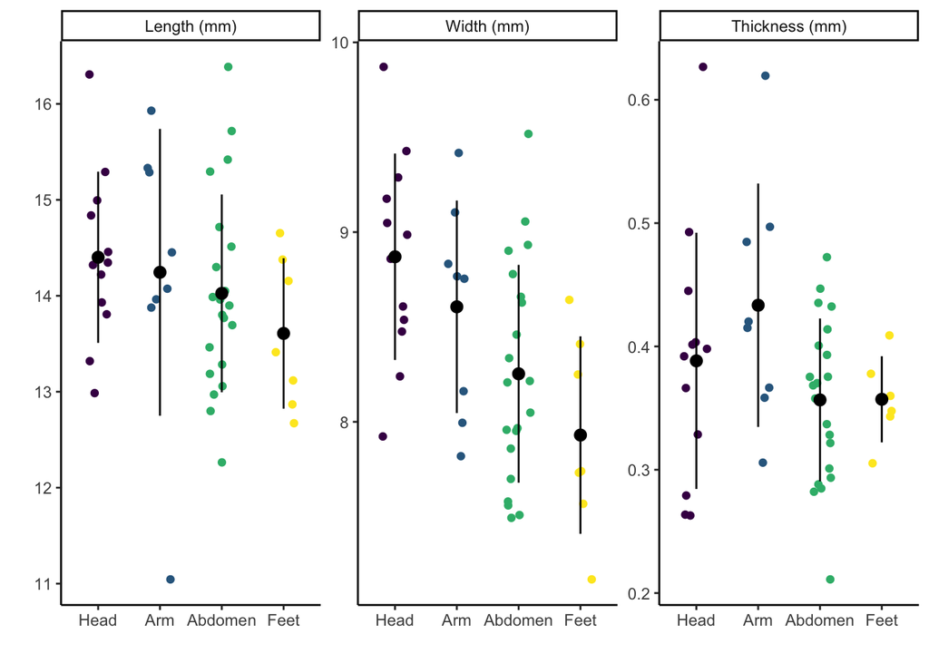

### Use-wear score

We computed the use-wear score using two methods.

#### Angle roundedness

The first one used the the VirtualGoniometer plugin in Meshlab on the microCT scans.

With this tool, we took a measurement at 8 points around each perforation, trying to target an angle when present.

However, as we used the plug-in, we realized that thickness of the shell may affect the results. The scatterplot presented below show that we were correct in our assumption, so we controlled for thickness by dividing the score by thickness for each shell.

The second graph shows that the controlled score is no longer correlated with Thickness, which is better.

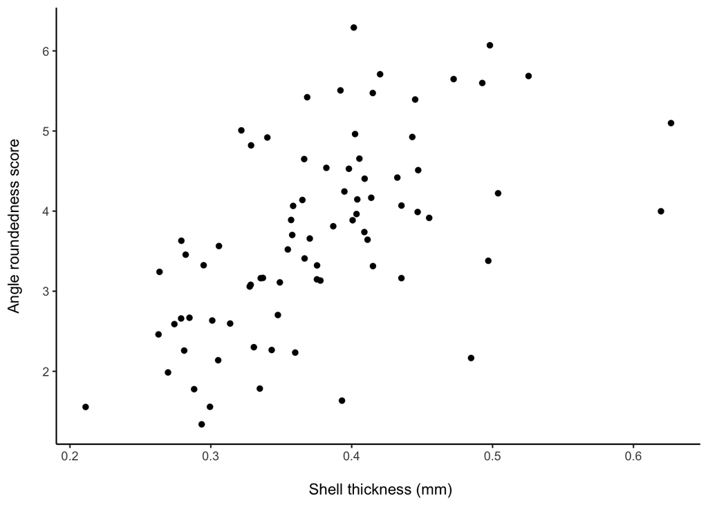

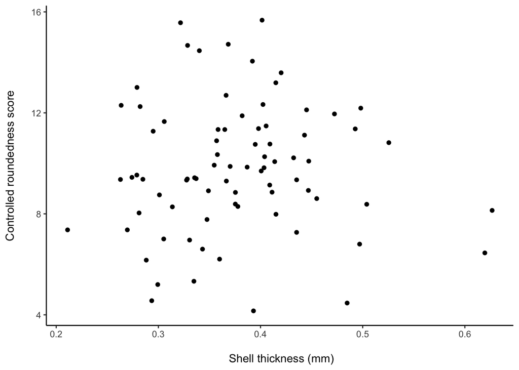

#### Surface roughness

The second method was done by Dr Zupancich. He extracted 3D areas around the perforation and divided it into 4 quadrants (see manuscript). He then used CloudCompare to calculate roughness in the quadrants, and randomly selected 100 points per quadrant for each shell.

He then performed some analysis on the dataset to see if roughness varies per part on the shell as well as if some shells show more roughness than others.

Comparing the scores of the two methods show that they follow a similar pattern, while not exactly the same.

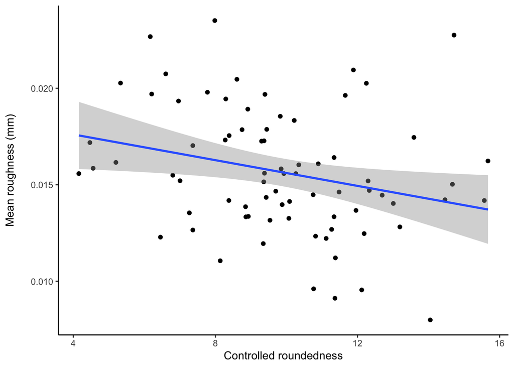

```
##
##  Pearson's product-moment correlation
##
## data:  use_wear$controlledScore and use_wear$mean_roughness
## t = -2.3833, df = 74, p-value = 0.01973
## alternative hypothesis: true correlation is not equal to 0
## 95 percent confidence interval:
##  -0.46449060 -0.04420047
## sample estimates:
##        cor
## -0.2669953
```

These results show that there is a fair significant correlation between the two scores, but they have significant differences, so we will use both for future tests, as they may capture different aspects of use-wear.

The following boxplot shows the differences in roughness around the hole for all shells. **NOTE that all outliers have been omitted here.**

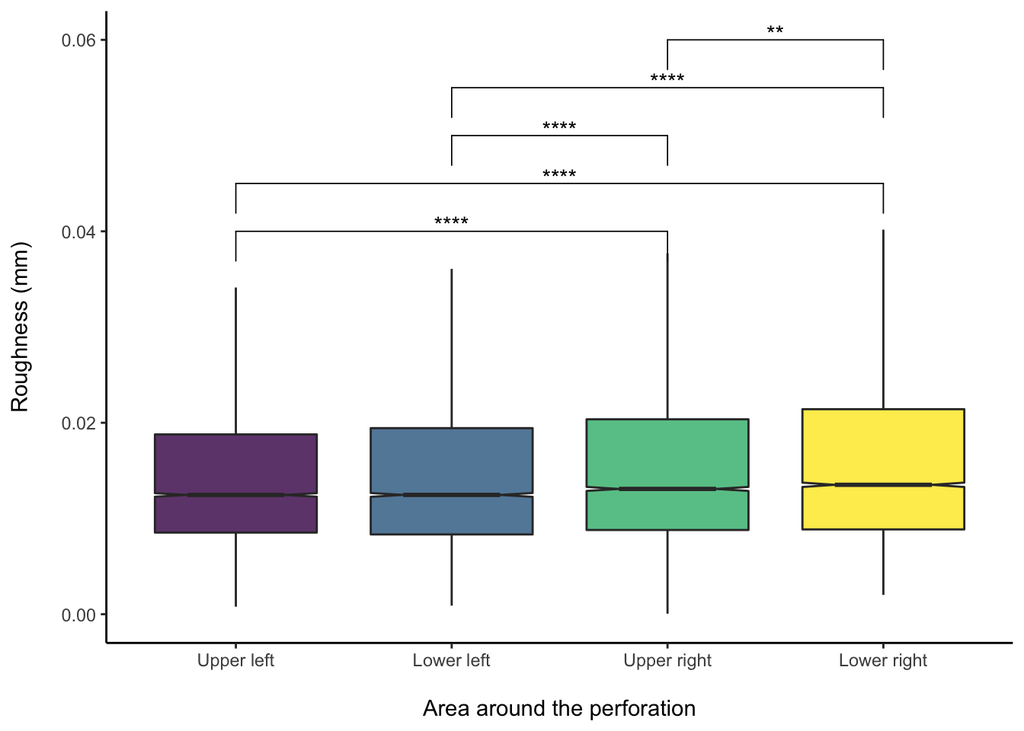

We performed Pairwise Wilcox test comparisons on Roughness vs perforation area.

```
##
##  Pairwise comparisons using Wilcoxon rank sum test with continuity correction
##
## data:  roughness_sampled$roughness and roughness_sampled$perf.area
##
##             Upper left Lower left Upper right
## Lower left  1.000      -          -
## Upper right 4.8e-07    1.6e-05    -
## Lower right 2.0e-15    1.0e-12    0.029
##
## P value adjustment method: bonferroni
```

And a Kruskall-Wallis rank sum test comparing Roughness vs perforation side.

```
##
##  Kruskal-Wallis rank sum test
##
## data:  roughness by perf.side
## Kruskal-Wallis chi-squared = 81.855, df = 1, p-value < 2.2e-16
```

This confirms the patterns shown by the microscope observations.

The graph below also shows a strong pattern where the left side is more worn than the right side.

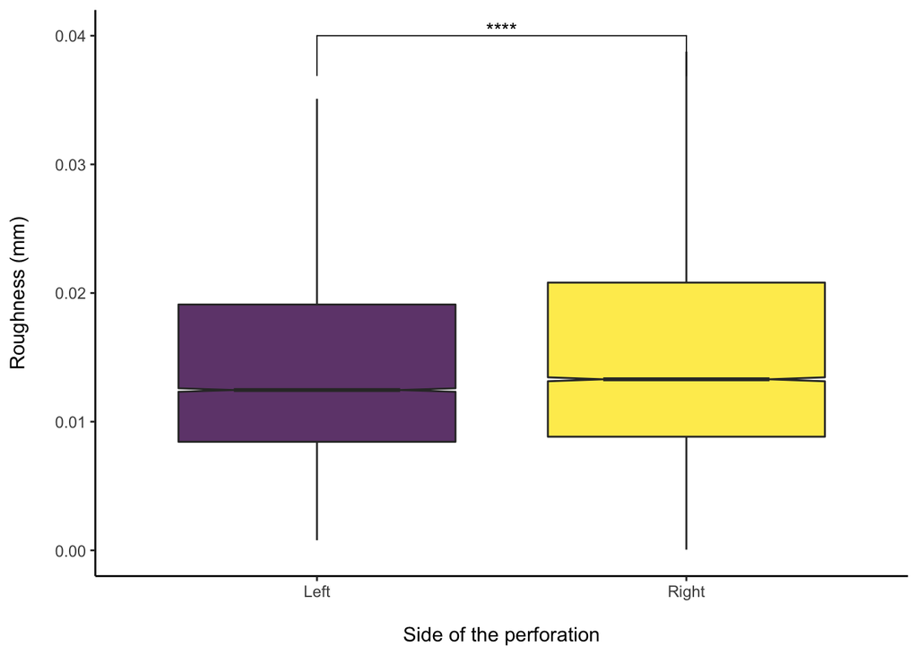

The following boxplot shows the differences in roughness and roundedness for shells divided by body region. This focuses only on the shells that were in in-situ arrangements. **NOTE that all outliers have been omitted here.**

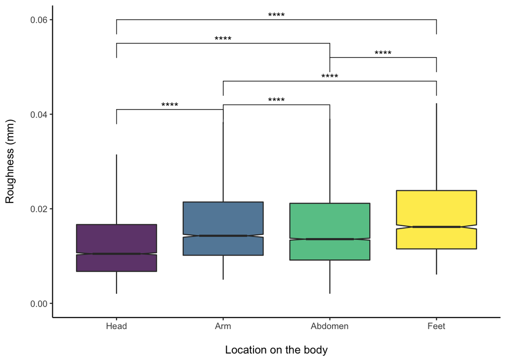

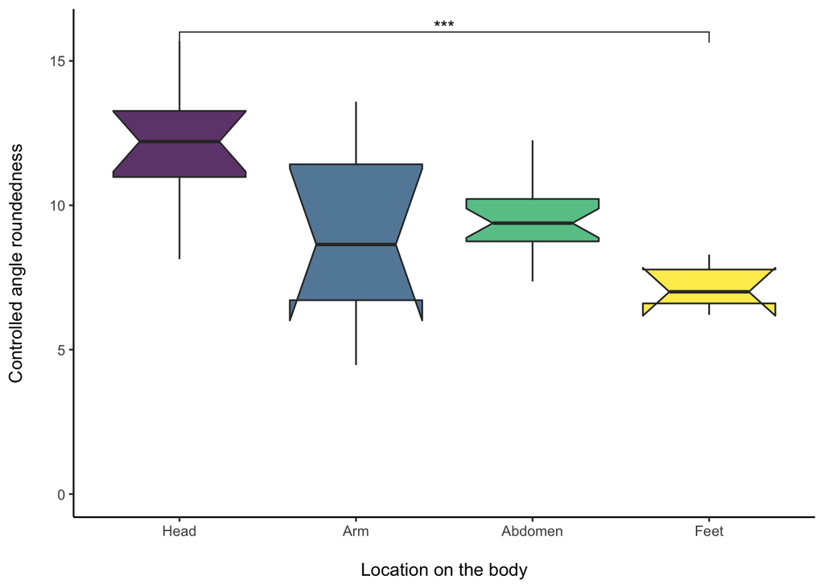

In the text, these results are summarized in a table rather than figure.

```
##
##  Pairwise comparisons using Wilcoxon rank sum exact test
##
## data:  use_wear_arr$mean_roughness and use_wear_arr$Location
##
##         Head   Arm    Abdomen
## Arm     0.0330 -      -
## Abdomen 0.1462 1.0000 -
## Feet    0.0078 1.0000 0.4721
##
## P value adjustment method: bonferroni
```

```
##
##  Pairwise comparisons using Wilcoxon rank sum exact test
##
## data:  use_wear_arr$controlledScore and use_wear_arr$Location
##
##         Head   Arm    Abdomen
## Arm     0.1208 -      -
## Abdomen 0.0600 1.0000 -
## Feet    0.0039 1.0000 0.1146
##
## P value adjustment method: bonferroni
```

However, does it mean that all worn shells are just around the head? In the figure below, we plot the mean roughness of shells against their geographical coordinates to show if there is any pattern.

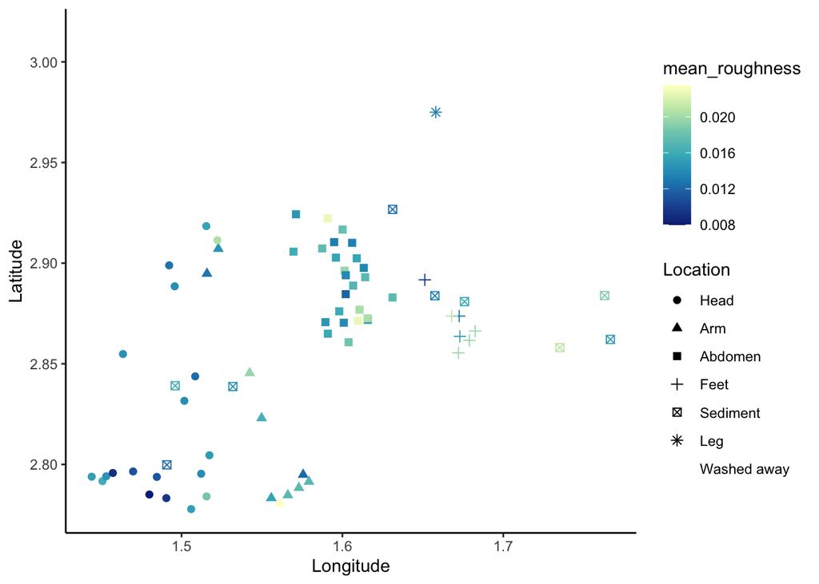

So, we do see some differences within arrangements as well.

# Statistical test for significant differences

## Correlation between sizes and use wear scores

First looking at correlation with length

```
##
##  Pearson's product-moment correlation
##
## data:  use_wear$Length and use_wear$mean_roughness
## t = -1.7337, df = 74, p-value = 0.08714
## alternative hypothesis: true correlation is not equal to 0
## 95 percent confidence interval:
##  -0.40497868  0.02919448
## sample estimates:
##        cor
## -0.1975614
```

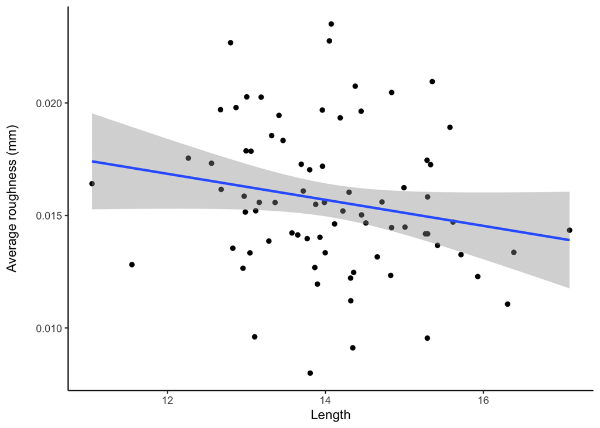

```
##
##  Pearson's product-moment correlation
##
## data:  use_wear$Length and use_wear$controlledScore
## t = 1.9096, df = 74, p-value = 0.06005
## alternative hypothesis: true correlation is not equal to 0
## 95 percent confidence interval:
##  -0.009188275  0.421573712
## sample estimates:
##       cor
## 0.2167162
```

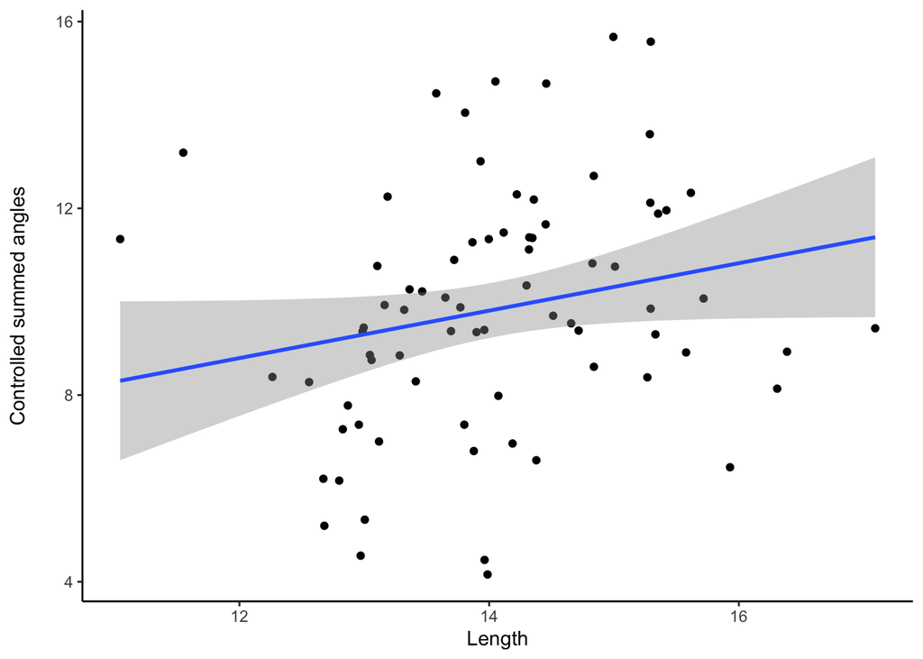

The correlation is not statistically significant for either use-wear score.

What about perforation area?

```
##
##  Pearson's product-moment correlation
##
## data:  use_wear$AreaPerf and use_wear$mean_roughness
## t = -2.9136, df = 74, p-value = 0.004722
## alternative hypothesis: true correlation is not equal to 0
## 95 percent confidence interval:
##  -0.5094103 -0.1027760
## sample estimates:
##        cor
## -0.3207982
```

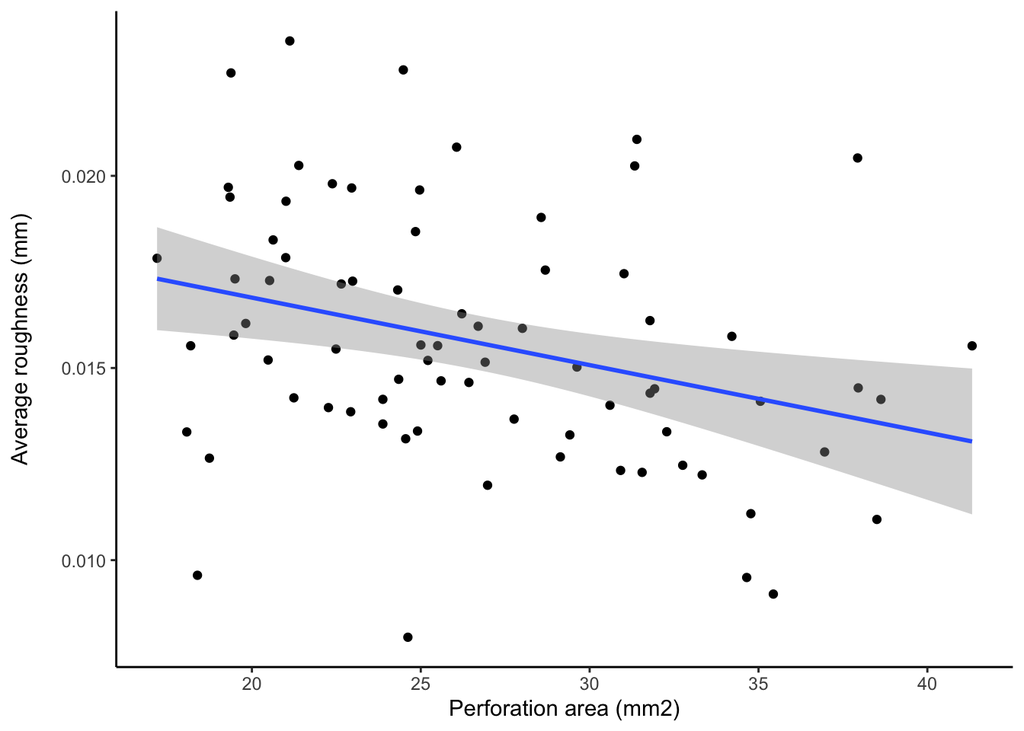

```
##
##  Pearson's product-moment correlation
##
## data:  use_wear$AreaPerf and use_wear$controlledScore
## t = 4.8382, df = 74, p-value = 6.957e-06
## alternative hypothesis: true correlation is not equal to 0
## 95 percent confidence interval:
##  0.2976587 0.6444464
## sample estimates:
##       cor
## 0.4902164
```

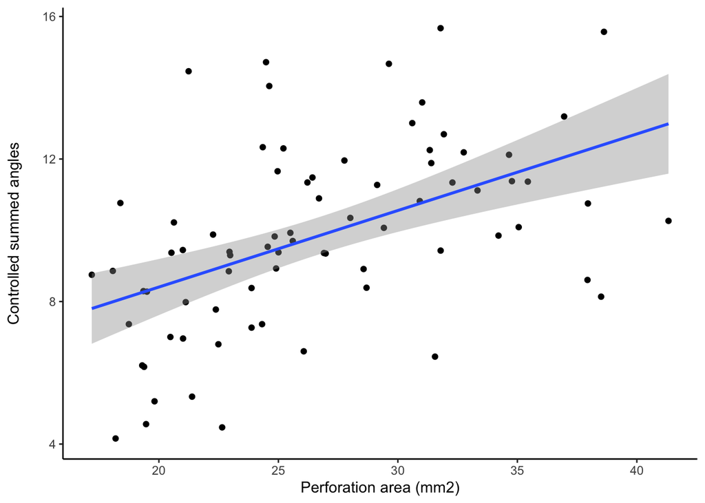

Both use-wear scores correlate significantly and relatively fairly with the size of the perforation. This suggests that perforation size might be an indicator of wear.

```
##
##  Pearson's product-moment correlation
##
## data:  use_wear$Thickness and use_wear$mean_roughness
## t = -3.3187, df = 74, p-value = 0.001405
## alternative hypothesis: true correlation is not equal to 0
## 95 percent confidence interval:
##  -0.5414499 -0.1463532
## sample estimates:
##        cor
## -0.3599323
```

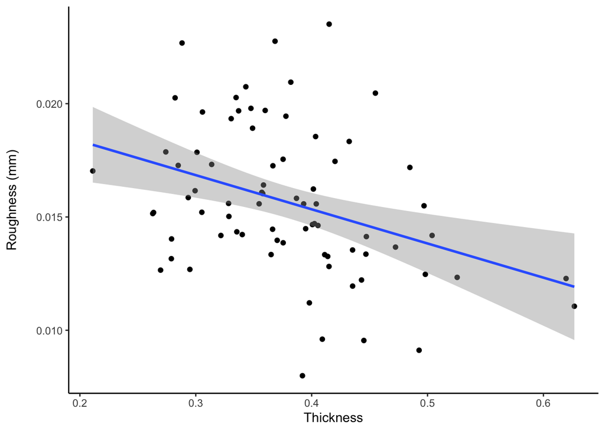

Interestingly, the roughness values also correlate with thickness. This is interesting. We need to investigate it further in the future.

### Slope and orientation

Looking at the slope and orientation of the shells in each group.

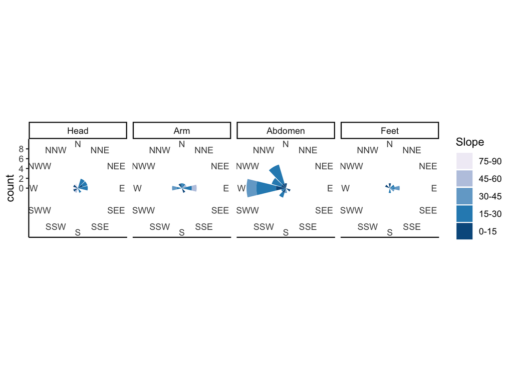

# Supplementary Information

The following table shows summary statistics of roughness per sample and per region around the perforation. These lines of code were written by AZ.

```
## # A tibble: 304 x 6
## # Groups:   PF [76]
##       PF perf.area   max_roughness min_roughness mean_roughness stD_roughness
##    <dbl> <ord>               <dbl>         <dbl>          <dbl>         <dbl>
##  1  2910 Upper left         0.0277       0.00405         0.0105       0.00557
##  2  2910 Lower left         0.0407       0.00415         0.0108       0.00684
##  3  2910 Upper right        0.0310       0.00407         0.0119       0.00623
##  4  2910 Lower right        0.0578       0.00400         0.0167       0.0129
##  5  2915 Upper left         0.0248       0.00704         0.0117       0.00428
##  6  2915 Lower left         0.0345       0.00715         0.0139       0.00619
##  7  2915 Upper right        0.0403       0.00717         0.0159       0.00723
##  8  2915 Lower right        0.0373       0.00710         0.0174       0.00700
##  9  2916 Upper left         0.0326       0.00903         0.0166       0.00562
## 10  2916 Lower left         0.0403       0.00910         0.0179       0.00806
## # … with 294 more rows
```

Summary statistics of roughness per perforation hole quadrant

```
## # A tibble: 4 x 5
##   perf.area   max_roughness min_roughness mean_roughness stD_roughness
## * <ord>               <dbl>         <dbl>          <dbl>         <dbl>
## 1 Upper left         0.0998      0.000786         0.0149       0.00912
## 2 Lower left         0.0974      0.000896         0.0153       0.0101
## 3 Upper right        0.0875      0.000056         0.0159       0.0101
## 4 Lower right        0.103       0.00202          0.0165       0.0106
```

Summary statistics of roughness per perforation hole side

```
## # A tibble: 2 x 5
##   perf.side max_roughness min_roughness mean_roughness stD_roughness
## * <ord>             <dbl>         <dbl>          <dbl>         <dbl>
## 1 Left             0.0998      0.000786         0.0151       0.00962
## 2 Right            0.103       0.000056         0.0162       0.0104
```

Summary statistics of roughness on shells located over the body

```
## # A tibble: 4 x 5
##   Location max_roughness min_roughness mean_roughness stD_roughness
## * <ord>            <dbl>         <dbl>          <dbl>         <dbl>
## 1 Head            0.0804       0.00202         0.0131       0.00926
## 2 Arm             0.103        0.00500         0.0174       0.0107
## 3 Abdomen         0.103        0.00204         0.0164       0.0101
## 4 Feet            0.0749       0.00609         0.0190       0.0101
```